# Neutral Theory

**Important**

A major question in evolutionary biology is, are most substitutions due to positive selection (adaptive) or random genetic drift?

## Neutral theory’s fundamental claim is that most molecular evolution is neutral and not adaptive.

Some descriptions of Neutral Theory…

**Definition**

most of the genetic differences between species is due to the fixation of neutral or nearly netural mutations by drift and not to the fixation of beneficial mutations by selection – Me

**Definition**

the claim that the vast majority of observed base substitutions are neutral with respect to fitness. – Herron and Freeman textbook

**Definition**

One of the many predictions that flow from that theory is that random genetic drift will cause genes to evolve at relatively constant rates. Kimura thought that beneficial mutations are so rare that they make only a trivial contribution to the molecular differences among species. Instead, Kimura believed that the vast majority of those differences result from the fixation of neutral mutations (those with s much smaller than 1/Ne). – Futuyma and Kirkpatrick textbook

**Definition**

The neutral theory of molecular evolution holds that most evolutionary changes occurring at the molecular level … are due to random genetic drift of mutant alleles that are selectively neutral. The theory applies only for evolution at the molecular level, and is compatible with phenotypic evolution being shaped by natural selection as postulated by Charles Darwin.– [Wikipedia](https://en.wikipedia.org/wiki/Neutral_theory_of_molecular_evolution)

## Substitutions are among-species differences in the nucleotide at a position on a DNA or in the amino acid at a position on a protein

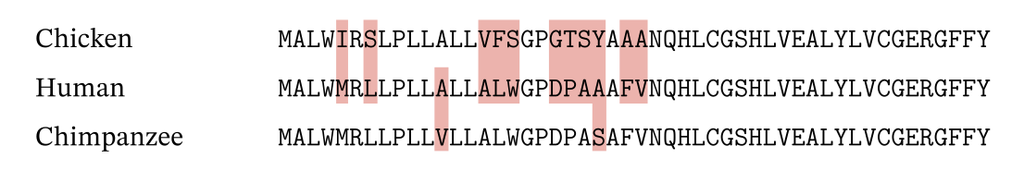

Amino acid sequence of part of the insulin protein of chicken, human, and chimpanzee

Since the most recent common ancestor of chimpanzee and human, the insulin gene has accumulated mutations in the lineage leading to chimpanzees and in the lineage leading to humans. The image above shows the amino acid sequence of a part of the insulin protein for human, chimpanzee, and chicken. Each letter is the standard single-letter abbreviation for an amino acid [(see the figure in the amino acid wikipedia entry)](https://en.wikipedia.org/wiki/Amino_acid). Differences in the amino acid at a position among the species are due to non-synonymous mutations in the insulin gene. In genetics, a different nucleotide at a position or a different amino acid at a position is called a [substitution](https://www.genome.gov/genetics-glossary/Substitution). In this part of the insulin protein, two amino acid substitutions (a difference at a specific locus) have evolved since the last common ancestor of human and chimpanzee.

**Question**

How many substitutions have evolved since the last common ancestor of human and chicken? Of chimpanzee and chicken?

**Better Know**

Positive selection: selection on beneficial mutations/alleles. Also called directional selection.

Negative selection: selection against deleterious mutations/alleles. Also called purifying selection.

## Initial motivation for Neutral Theory

1. **Clock-like rate of amino-acid substitution in protein evolution**. Motoo Kimura introduced Neutral Theory in 1968 but between 1963 and 1965, biologists had recognized a clock-like rate of amino acid substitution in protein evolution that suggested most amino acid substitutions are neutral with respect to fitness. That is

**Important**

The clock-like rate suggests most amino acid subsitutions result in small changes in protein function (say the ability of hemoglobin to bind O2) and these small changes in function have little to no effect on fitness (not big enough to overwhelm drift).

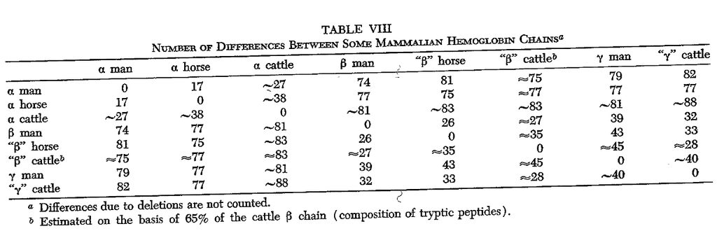

Number of amino acid substitutions for alpha and beta chains of hemoglobin. Using estimated times of divergence of human, cow, and horse, Zuckerandle and Pauling estimated the rate of substitution and found a linear relationship between divergence time and number of substitutions – from Zuckerandl and Pauling 1965

In addition, the rate of substitution is **functionally constrained**, That is the rate is slow in proteins with critical cell function and fast in proteins with less critical function. See the figure below and also Fig 7.25 in the textbook. Why is this important to the idea of neutral theory?

**Important**

The correlation between substitution rate and protein function also suggests neutral theory. If all substitutions had an effect on fitness, then all rates would be low.

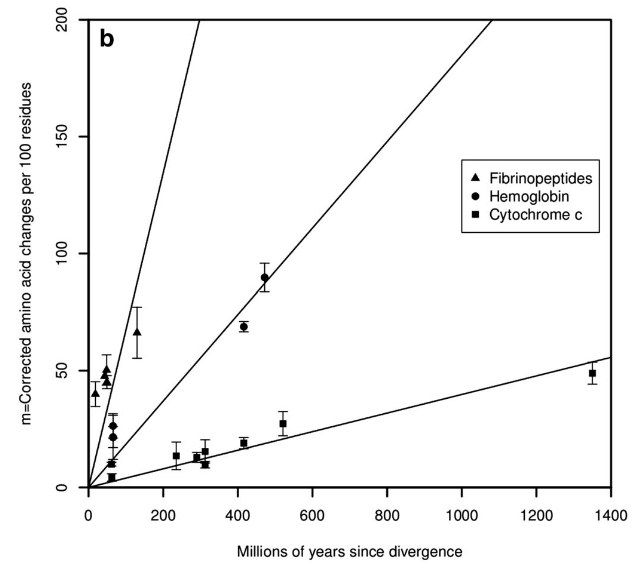

Clock-like rate of substitution of amino acids in three different proteins. The rate is the slope of the line. The different rates are due to functional constraints. Highly critical proteins like Cytochrome C have slow rates. Less critical proteins like fibrinopeptides have faster rates. The data are modern amino acid sequence data to replicate the famous finding from Dickerson 1971 – from Robinson et al. 2016

2. The second motivation is described in 7.3 of the Herron and Freeman Textbook

**Quotation**

Kimura took the number of sequence differences in the well-studied proteins of humans versus horses and converted them to rates of sequence change over time using divergence dates estimated from the fossil record. He then extrapolated these rates to all of the protein-coding loci in the genome. The result implied that as the two lineages diverged from their common ancestor, mutations leading to amino acid replacements had, on average, risen to fixation once every two years. Given that most mutations are thought to be deleterious, this rate seemed too high to be due to natural selection. Beneficial mutations fixed by natural selection should be rare. – *7.3 of Herron and Feeman*

The reasoning is is known as Haldane’s dilemma and goes something like this: The positive selection required to fix a mutation requires a certain number of deaths of the carriers of the old variant. The fixation of the many, many amino acid substitutions within a gene and across multiple genes separating two lineages (humans and cow), would require huge population sizes to accommodate the number of deaths required. Drift of course doesn’t require any number of deaths. Therefore, most of these substitutions cannot be by positive selection and must be by drift.

## Potential Problems with Neutral theory

### The molecular clock is a constant per year rate

**Quotation**

According to the neutral theory of molecular evolution, the rate at which molecular changes accumulate between species should be equal to the rate of neutral mutations and hence relatively constant across species. However, this is a per-generation rate. Since larger organisms have longer generation times, the neutral theory predicts that their rate of molecular evolution should be slower. However, molecular evolutionists found that rates of protein evolution were fairly independent of generation time. – [Wikipedia entry on Nearly Neutral Theory](https://en.wikipedia.org/wiki/Nearly_neutral_theory_of_molecular_evolution)

Neutral theory predicts a constant rate of nucleotide/amino acid substitution **per generation** (what the textbook calls “generation time”). Since organisms very in the rate of producing a new generation, Neutral theory predicts faster **per year** rates in organisms with more generations per year.

This is at odds with initial work on on the molecular clock, which showed a constant rate of substition **per year** (what the textbook calls “clock time”) even when including organisms with very different generation rates (rats produce three generations per year. A generation is humans is about 20 years so that is 1/20 or 0.05 generations per year).

Why does neutral theory predict a constant rate of nucleotide/amino acid substitution per generation?

$$\texttt{substitutions per generation} = \texttt{new mutations per generation} \times \texttt{probability of fixation by drift}$$
Okay, there are $N$ individuals in the population, each carrying 2 copies of the allele (here let’s use “nucleotide at a specific locus” as what we mean by “allele”). This means there are $2N$ different copies of the allele in the **gene pool**. How many of these $2N$ alleles will have a mutation in the gamete?

$$\texttt{New mutations} = 2N\mu$$

We multiply the Number of alleles that could be mutated ($2N$) by the mutation rate ($\mu$) to get the expected number of mutations in the population.

This should make sense. If we have 100 students in class and the rate of A’s per student is .8 then we expect $100 \times .8 = 80$ A’s in the class.

The probability of fixation by drift is the frequency of the allele (Herron and Freeman Computing Consequences 7.3), so for a new mutation, with only one copy in the gene pool, this is $\frac{1}{2N}$

The expected substitution rate by genetic drift then is

$$\texttt{substitutions per generation} = 2N\mu \times \frac{1}{2N} = \mu$$

So the per-generation rate is equal to the mutation rate, which is independent of population size. So, again, if the generation rate of lineage A is twice that of lineage B (say, two generation per year vs. one), then Neutral Theory would predict the per-year substitution rate to be twice as big in lineage A. Or more generally

$$\texttt{substitutions per year} = \mu \times \texttt{generations per year}$$
### But…Nearly Neutral Theory predicts a constant per-year rate

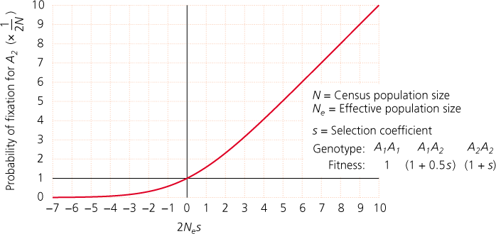

Herron and Freeman Figure 7.23

The plot in Figure 7.23 of Herron and Freeman is wicked important for understanding the competing forces of drift and selection. The *y*-axis is the probability of the fixation of a mutation under drift + selection *relative to* that for a mutation under genetic drift only (a neutral mutation). The red line is the function $f({2Ns})$. Understand how to use this!

**How to think about a function**

The **Nearly Neutral Theory** uses the math underneath the function creating the red line to show that genetic drift of nearly neutral mutation predicts a constant per-year rate of the molecular clock.

The logic is something like

**Important**

A nearly neutral mutation is not simply determined by a small $s$! What makes a mutation nearly neutral is the selection coefficient *relative to* the reciprocal of population size!

$$\texttt{substitutions per year} = 2N\mu \times f({2Ns}) \times g$$

**Important**

Nearly Neutral Theory predicts the expected rate of substitution as slightly slower than the mutation rate **per year** and not per generation!

## Testing Neutral Theory

more to come…